# DISCRETE DISTRIBUTIONS

Rigam bhaduri

2025-06-07

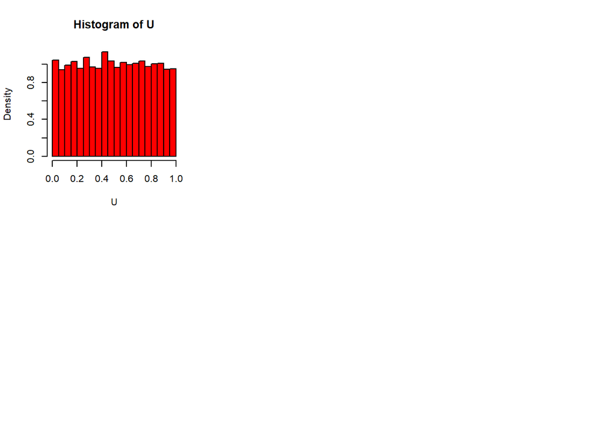

```r
# DISCRETE DISTRIBUTIONS

set.seed(123)
n <- 10000
U <- runif(n,min = 0,max = 1)
p <- 0.3
k <- 10
par(mfrow=c(2,3))
hist(U, probability = T, col = "red")
```

Let $U \sim \text{Uniform}(0,1)$. We can generate $X \sim \text{Bernoulli}(p)$ as:
$$X = \begin{cases}
1 & \text{if } U \leq p \\
0 & \text{if } U > p
\end{cases}$$
This satisfies:
$$P(X = 1) = P(U \leq p) = p$$
$$P(X = 0) = P(U > p) = 1 - p$$

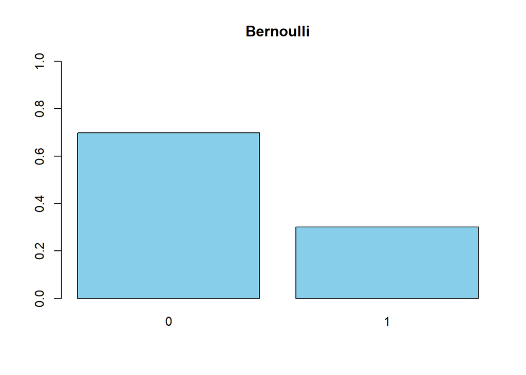

```r
# 1. Bernoulli(p)

X <- ifelse(U <= p, 1, 0)  # Transform to Bernoulli
barplot(table(X)/n, main="Bernoulli", col="skyblue", ylim=c(0,1))
```

```r
#-----Visulize the Bernouli distribution-------
cat("Bernoulli mean (should be close to p =", p, "):", mean(X), "\n")
```

```
## Bernoulli mean (should be close to p = 0.3 ): 0.3012
```

$\textbf{From Bernoulli to Binomial: Mathematical Derivation}$

$\textbf{Bernoulli Distribution:}$

A random variable $X$ follows $\text{Bernoulli}(p)$ if:
$$P(X=1) = p \quad \text{and} \quad P(X=0) = 1-p$$

$\textbf{Binomial Distribution}$: A random variable $Y$ follows $\text{Binomial}(n,p)$ if:
$$P(Y=k) = \binom{n}{k} p^k (1-p)^{n-k}, \quad k=0,1,\dots,n$$
$\textbf{Conversion Process}$

The Binomial distribution arises as the sum of $n$ independent Bernoulli trials:

$$Y = \sum_{i=1}^n X_i \quad \text{where} \quad X_i
\overset{\text{i.i.d.}}{\sim} \text{Bernoulli}(p)$$

$\textbf{Expectation}$:
$$E[Y] = E\left[\sum_{i=1}^n X_i\right] = \sum_{i=1}^n E[X_i] = n p$$

$\textbf{Variance}$ (using independence):
$$\text{Var}(Y) = \text{Var}\left(\sum_{i=1}^n X_i\right) = \sum_{i=1}^n
\text{Var}(X_i) = n p (1-p)$$

$\textbf{Probability Mass Function}$: Each specific sequence with $k$ successes has probability $p^k (1-p)^{n-k}$ There are $\binom{n}{k}$ such sequences Thus: $P(Y=k) = \binom{n}{k} p^k (1-p)^{n-k}$

$\textbf{Generation Algorithm}$

Given $U_1, \dots, U_n \sim \text{Uniform}(0,1)$:

Generate Bernoulli variates:
$$X_i = \mathbb{I}(U_i \leq p) =
\begin{cases}
1 & \text{if } U_i \leq p \\
0 & \text{otherwise}
\end{cases}$$

Sum to get Binomial variate:
$$Y = \sum_{i=1}^n X_i$$

```r
# 2 Binomial(n,p)

U_binomial <- matrix(runif(n * k), nrow = n, ncol = k)
Y <- rowSums(U_binomial <= p)  # Sum Bernoulli trials per row

# Check mean (should approach k*p)
cat("Binomial mean (should be close to k*p =", k*p, "):", mean(Y), "\n")
```

```
## Binomial mean (should be close to k*p = 3 ): 3.0018
```

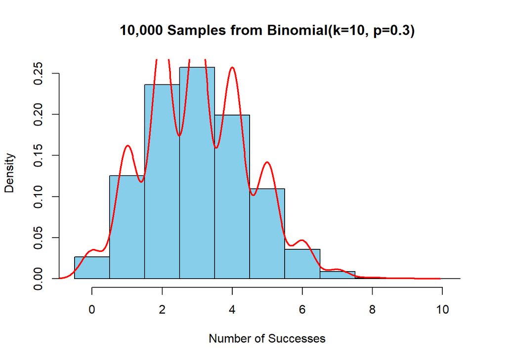

```r
# --- Visualize the Binomial samples ---
hist(Y,
     breaks = seq(-0.5, k + 0.5, by = 1),
     main = "10,000 Samples from Binomial(k=10, p=0.3)",
     xlab = "Number of Successes",
     col = "skyblue",
     freq = FALSE)
lines(density(Y, adjust = 1.5), col = "red", lwd = 2)  # Optional: Add smoothed density
```

$\textbf{Relationship Between Binomial and Geometric Distributions}$

Let $X_1, X_2, \ldots$ be independent $\text{Bernoulli}(p)$ trials (which are $\text{Binomial}(1,p)$ random variables). Then:

$\textbf{Fundamental Definitions}$

The $\textbf{Binomial(n,p)}$ distribution counts the number of successes in $n$ trials:
$$Y_n = \sum_{i=1}^n X_i \sim \text{Binomial}(n,p)$$

The $\textbf{Geometric(p)}$ distribution counts the trials until the first success:
$$G = \min\{k \in \mathbb{N} \mid X_k = 1\} \sim \text{Geometric}(p)$$

$\textbf{Probability Mass Functions}$

$$\begin{eqnarray}
\text{Binomial}(n,p): & \quad P(Y_n = k) =
\binom{n}{k}p^k(1-p)^{n-k}, \quad k = 0,1,\ldots,n \\
\text{Geometric}(p): & \quad P(G = k) = (1-p)^{k-1}p, \quad k =
1,2,\ldots
\end{eqnarray}$$

$\textbf{Conversion Relationship}$

To generate $G \sim \text{Geometric}(p)$ from $\text{Binomial}(1,p)$ trials:
$$G \overset{d}{=} \inf\left\{ k \geq 1 : \sum_{i=1}^k X_i \geq 1 \right\}$$
where $\overset{d}{=}$ denotes equality in distribution.

$\textbf{Moments}$

$$\begin{eqnarray}
E[G] &= \frac{1}{p} \\
\text{Var}(G) &= \frac{1-p}{p^2}
\end{eqnarray}$$

$\textbf{Interpretation}$

This shows that while: 1. The Binomial distribution counts successes in a fixed number of trials 2. The Geometric distribution counts trials until the first success

making the Geometric distribution a special case of the Negative Binomial distribution with $r=1$ success required.

```r
# 3. Geometric(p)

# Function to generate Geometric(p) from Binomial(1,p) trials
generate_geometric <- function(n,p) {
  geometric_samples <- numeric(n)

  for (i in 1:n) {
    count <- 0
    success <- FALSE

    while (!success) {
      count <- count + 1
      # Generate a single Bernoulli trial (Binomial with n=1)
      trial <- rbinom(1, 1, p)
      if (trial == 1) {
        success <- TRUE
      }
    }

    geometric_samples[i] <- count
  }

  return(geometric_samples)
}

# Generate Geometric samples
geom_samples <- generate_geometric(n, p)

# Check statistics (mean should approach 1/p)
cat("Geometric mean (should be close to 1/p =", 1/p, "):", mean(geom_samples), "\n")
```

```
## Geometric mean (should be close to 1/p = 3.333333 ): 3.2862
```

```r
cat("Geometric variance (should be close to (1-p)/p^2 =", (1-p)/p^2, "):", var(geom_samples), "\n")
```

```
## Geometric variance (should be close to (1-p)/p^2 = 7.777778 ): 7.442634
```

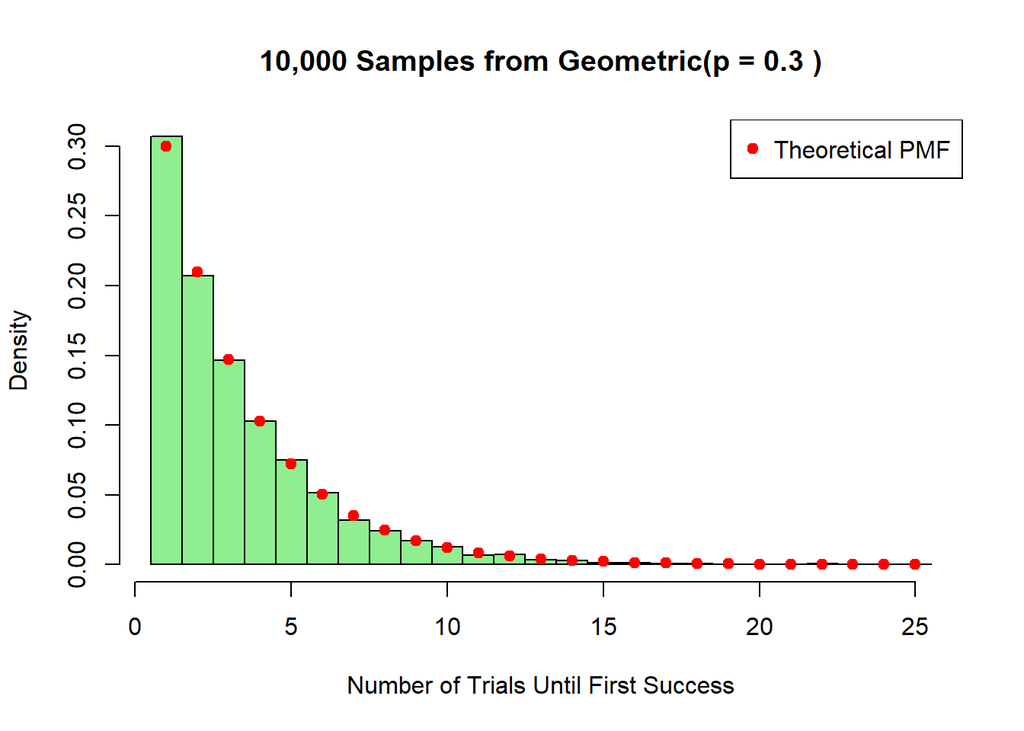

```r
# --- Visualize the Geometric samples ---
hist(geom_samples,
     breaks = seq(0.5, max(geom_samples)+0.5, by = 1),
     main = paste("10,000 Samples from Geometric(p =", p, ")"),
     xlab = "Number of Trials Until First Success",
     col = "lightgreen",
     freq = FALSE)

# Add theoretical PMF
x_vals <- 1:max(geom_samples)
points(x_vals, dgeom(x_vals-1, p), col = "red", pch = 19)  # Note: dgeom uses k-1
legend("topright", legend = "Theoretical PMF", col = "red", pch = 19)
```

$\textbf{Geometric Distribution}$ Let $G \sim \text{Geometric}(p)$ with probability mass function:
$$P(G = k) = (1-p)^{k-1}p \quad \text{for } k = 1, 2, 3, \ldots$$
where $p$ is the success probability per trial.

$\textbf{Poisson Distribution}$ Let $P \sim \text{Poisson}(\lambda)$ with probability mass function:
$$P(P = k) = \frac{e^{-\lambda}\lambda^k}{k!} \quad \text{for } k = 0, 1,
2, \ldots$$

$\textbf{Conversion Methodology}$

$\textbf{Approach via Sum of Geometric Variables}$ The sum of $n$ independent Geometric($p$) random variables follows a Negative Binomial distribution:

$$S_n = \sum_{i=1}^n G_i \sim \text{NegativeBinomial}(n, p)$$

Under the following conditions as $n \to \infty$ and $p \to 0$ while maintaining $n(1-p)/p \to \lambda$:

$\textbf{Conversion Steps}$

$\textbf{Approximation Quality}$

The approximation improves when:
$$p < 0.1 \quad \text{and} \quad \lambda < 5$$

The error can be quantified using the total variation distance:
$$d_{TV}(\text{NegativeBinomial}(n,p), \text{Poisson}(\lambda)) \leq
\frac{p}{1-p}$$

$\textbf{Limitations}$

1. The approximation deteriorates for large $\lambda$ values
2. Direct Poisson generation via is preferred for exact samples
3. Mainly useful for pedagogical demonstrations of distributional relationships

```
## Poisson mean: 6.5724  (target: 4 )
## Poisson variance: 14.40884
```

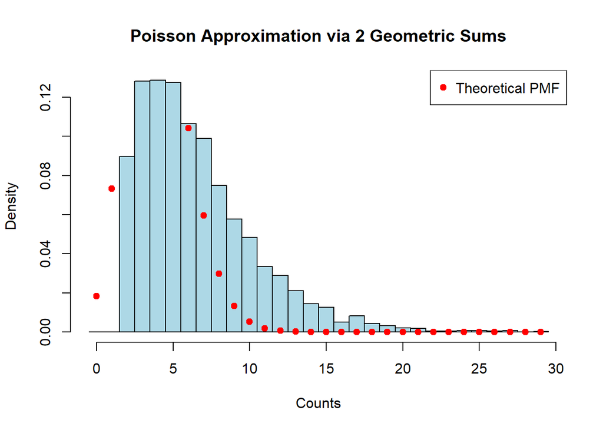

```r
# 4. Poisson(lambda=4)

lambda <- 4  # Target Poisson parameter
# 2. Convert to Poisson - Method 1: Sum of Geometrics
convert_to_poisson <- function(geom_samples, target_lambda, p) {
  # Calculate how many Geometrics to sum
  k <- max(1, round(target_lambda * p / (1 - p)))

  # Make sure we have enough samples
  n <- length(geom_samples)
  m <- floor(n/k)

  # Reshape and sum
  matrix(geom_samples[1:(m*k)], ncol = k) |> rowSums()
}

pois_samples <- convert_to_poisson(geom_samples, lambda, p)

# 3. Check results
if (all(is.finite(pois_samples))) {
  cat("Poisson mean:", mean(pois_samples), " (target:", lambda, ")\n")
  cat("Poisson variance:", var(pois_samples), "\n")

  # Visualization
  hist(pois_samples,
       breaks = seq(-0.5, max(pois_samples)+0.5, by = 1),
       main = paste("Poisson Approximation via", round(lambda*p/(1-p)), "Geometric Sums"),
       xlab = "Counts",
       col = "lightblue",
       freq = FALSE)
  points(0:max(pois_samples), dpois(0:max(pois_samples), lambda),
         col = "red", pch = 19)
  legend("topright", legend = "Theoretical PMF", col = "red", pch = 19)
} else {
  warning("Non-finite values detected in Poisson samples")
}
```

$\textbf{Conversion from Poisson to Negative Binomial}$

$\textbf{Theoretical Foundation}$

$\textbf{Parameter Conversion}$

The mixture emerges from the integral:
$$\begin{equation}
P(X=k) = \int_0^\infty \frac{e^{-\lambda}\lambda^k}{k!} \cdot
\frac{\beta^r}{\Gamma(r)} \lambda^{r-1} e^{-\beta\lambda} \, d\lambda
\end{equation}$$

Solving yields the Negative Binomial PMF:
$$\begin{equation}
P(X=k) = \frac{\Gamma(r+k)}{k!\,\Gamma(r)}
\left(\frac{\beta}{1+\beta}\right)^r \left(\frac{1}{1+\beta}\right)^k
\end{equation}$$

$\textbf{Limiting Behavior}$

When $r \to \infty$ while maintaining $\lambda = \frac{r(1-p)}{p}$ constant:
$$\begin{equation}
\text{NegativeBinomial}(r,p) \xrightarrow{d} \text{Poisson}(\lambda)
\end{equation}$$

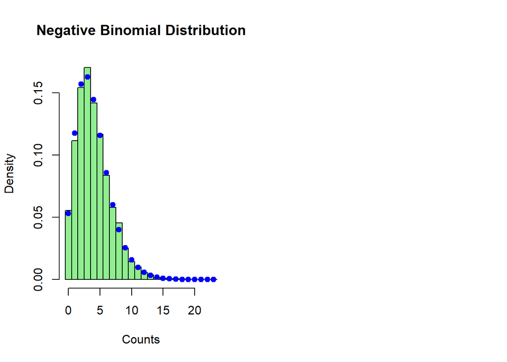

```r
# 5. Negative Binomial (size=5, prob=0.3)

lambda <- 4
target_r <- 5
target_p <- target_r/(target_r + lambda)

convert_to_negbin <- function(pois_samples, r, lambda) {
  p <- r/(r + lambda)
  rnbinom(length(pois_samples), size = r, prob = p)
}
negbin_samples <- convert_to_negbin(pois_samples, target_r, lambda)

# Visualization
par(mfrow = c(1, 2))
hist(negbin_samples,
     breaks = seq(-0.5, max(negbin_samples)+0.5, by = 1),
     main = "Negative Binomial Distribution",
     xlab = "Counts",
     col = "lightgreen",
     freq = FALSE)
points(0:max(negbin_samples), dnbinom(0:max(negbin_samples), size = target_r, prob = target_p),
       col = "blue", pch = 19)
```

$\textbf{Conversion from Uniform to Multinomial Distribution}$

$\textbf{Mathematical Framework}$

Given a multinomial distribution with $k$ categories and probability vector $\mathbf{p} = (p_1, p_2, \dots, p_k)$ where $\sum_{i=1}^k p_i = 1$, we can generate samples using uniform random variables $U \sim \text{Uniform}(0,1)$.

$\textbf{Conversion Algorithm}$

1. Generate independent uniform random variables:
   $$\begin{equation}
   U_1, U_2, \dots, U_n \overset{\text{iid}}{\sim} \text{Uniform}(0,1)
   \end{equation}$$
2. Construct cumulative probabilities:
   $$\begin{equation}
   c_0 = 0, \quad c_i = \sum_{j=1}^i p_j \quad \text{for } i = 1, \dots, k
   \end{equation}$$
3. For each $U_m$, determine the category:
   $$\begin{equation}
   X_m = \sum_{i=1}^k i \cdot \mathbb{I}_{[c_{i-1}, c_i)}(U_m)
   \end{equation}$$
   where $\mathbb{I}$ is the indicator function.
4. The resulting counts follow:
   $$\begin{equation}
   \mathbf{N} = (N_1, \dots, N_k) \sim \text{Multinomial}(n, \mathbf{p})
   \end{equation}$$
   where $N_i = \sum_{m=1}^n \mathbb{I}\{X_m = i\}$.

$\textbf{Mathematical Justification}$

The transformation works because:
$$\begin{equation}
P(X_m = i) = P(U_m \in [c_{i-1}, c_i)) = c_i - c_{i-1} = p_i
\end{equation}$$

For $n$ trials, the joint distribution becomes:
$$\begin{equation}
P(\mathbf{N} = \mathbf{n}) = \frac{n!}{n_1! \cdots n_k!} \prod_{i=1}^k
p_i^{n_i}
\end{equation}$$

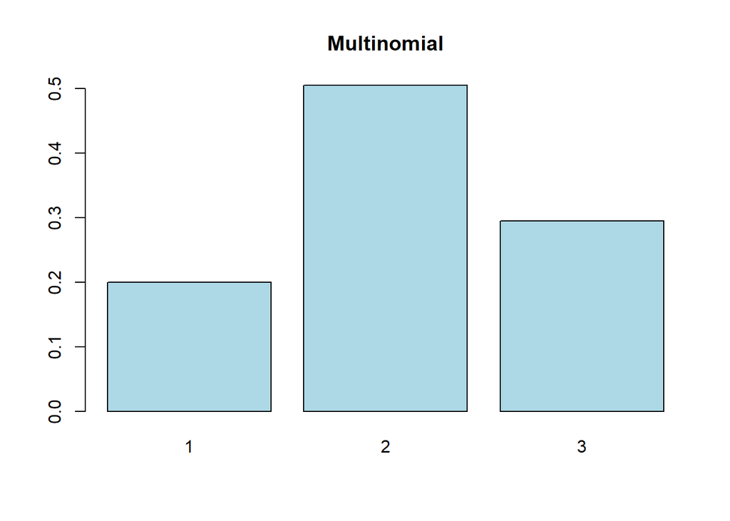

```r
# 6. Multinomial (1 trial, probs = c(0.2, 0.5, 0.3))

p <- c(0.2, 0.5, 0.3)  # Probability vector (must sum to 1)

# Generate multinomial samples from uniform
cum_p <- cumsum(p)
multinomial_samples <- sapply(U, function(u) {
  which.max(u <= cum_p)
})

# Convert to counts
counts <- table(factor(multinomial_samples, levels = 1:k))
barplot(table(multinomial_samples)/n, main="Multinomial", col="lightblue")
```

$\textbf{Conversion from Multinomial to Discrete Uniform Distribution}$

$\textbf{Problem Definition}$

Given a multinomial random variable $X \sim \text{Multinomial}(1, \mathbf{p})$ with probability vector $\mathbf{p} = (p_1, p_2, \dots, p_k)$ where $\sum_{i=1}^k p_i = 1$, we want to transform it to a discrete uniform random variable $Y \sim \text{Uniform}\{1, 2, \dots, k\}$ with $P(Y=i) = \frac{1}{k}$ for all $i$.

$\textbf{Transformation Method}$

1. Generate $U \sim \text{Uniform}(0,1)$
2. For multinomial distribution:
   $$\begin{equation}
   X = \min\left\{j \in \{1,\dots,k\} : \sum_{i=1}^j p_i \geq U\right\}
   \end{equation}$$
3. For discrete uniform distribution:
   $$\begin{equation}
   Y = \lceil kU \rceil
   \end{equation}$$
   where $\lceil \cdot \rceil$ is the ceiling function.

$\textbf{Mathematical Justification}$

The transformation works because:

$$\begin{equation}
P(Y = i) = P\left(\frac{i-1}{k} < U \leq \frac{i}{k}\right) =
\frac{i}{k} - \frac{i-1}{k} = \frac{1}{k}
\end{equation}$$

This creates equal-width bins in $[0,1]$:

$$[0,1] = \bigcup_{i=1}^k \left(\frac{i-1}{k}, \frac{i}{k}\right]$$

$\textbf{Properties}$

$\textbf{Alternative Approach}$

If preserving some multinomial structure is desired, we can use:

$$\begin{equation}
Y = F^{-1}(F_X(X) \cdot U')
\end{equation}$$

where: 1. $F_X$ is the CDF of the multinomial 2. $U' \sim \text{Uniform}(0,1)$ 3. $F^{-1}$ is the inverse CDF of the uniform

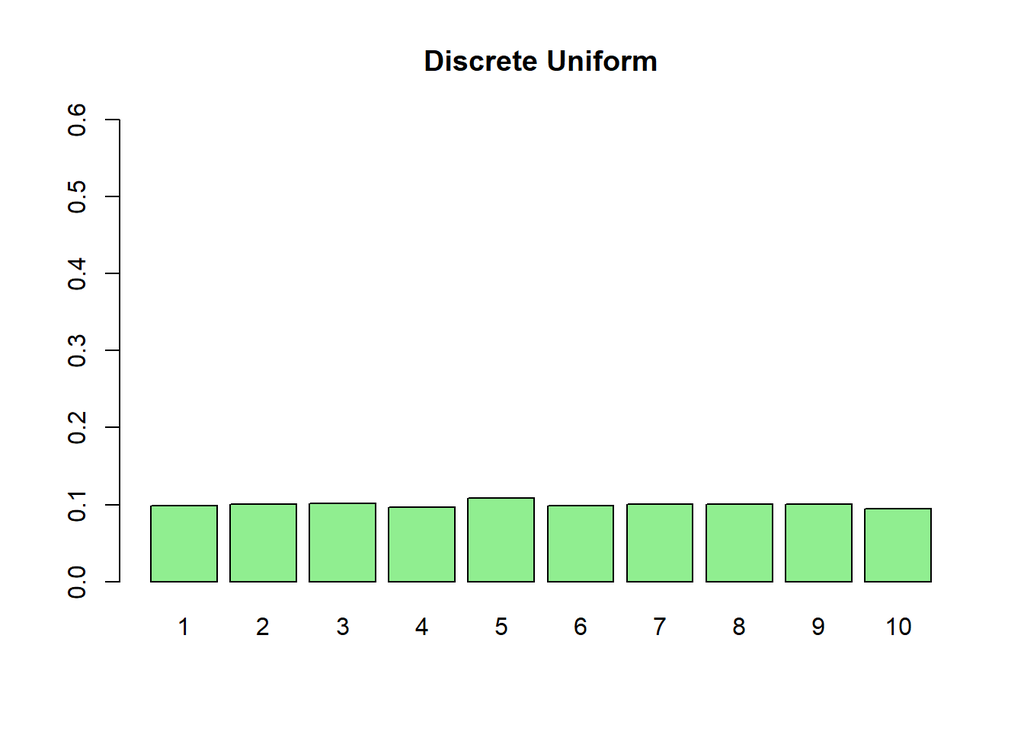

```r
# 7. Discrete custom (say values = 1, 3, 5 with probs = 0.2, 0.5, 0.3)

# Convert to uniform by redistributing probabilities
# Method: Inverse transform with equal-width bins
uniform_samples <- sapply(U, function(u) {
  ceiling(u * k)  # Equal bins of width 1/k
})
barplot(table(uniform_samples)/n,
        main = "Discrete Uniform",
        col = "lightgreen",
        ylim = c(0, 0.6))
```